# Scikit-Learn

转自：[【Python数据科学手册】Scikit-Learn简介](https://tianchi.aliyun.com/course/courseConsole?spm=5176.12282070.0.0.60112042P4GIRT&courseId=306&chapterIndex=1&sectionIndex=2)并做适当增删。

## Scikit-Learn的数据表示

### 数据表

[Seaborn](http://seaborn.pydata.org)是基于matplotlib的Python可视化库,它提供了一个高级界面来绘制有吸引力的统计图形，iris是鸢尾花数据集。

```python
import seaborn as sns
iris = sns.load_dataset('iris') #type(iris) -> pandas.core.frame.DataFrame
iris.head()
```

|  | sepal_length | sepal_width | petal_length | petal_width | species |
| --- | --- | --- | --- | --- | --- |
| 0 | 5.1 | 3.5 | 1.4 | 0.2 | setosa |
| 1 | 4.9 | 3.0 | 1.4 | 0.2 | setosa |
| 2 | 4.7 | 3.2 | 1.3 | 0.2 | setosa |
| 3 | 4.6 | 3.1 | 1.5 | 0.2 | setosa |
| 4 | 5.0 | 3.6 | 1.4 | 0.2 | setosa |

每一行表示一个样本（sample），行数表示样本数，记为n_samples；同样，每一列表示一个特征(feature)，列数记为n_features 。

### 特征矩阵

上面的表格称为**特征矩阵（features matrix）**，通常被简记为变量$X$，维度为[n_samples,n_features],可以使用NumPy的数组、Pandas的DataFrame来表示，不过Scikit-Learn也支持[SciPy](https://www.scipy.org/)的稀疏表示。

### 目标数组

目标数组**一般**是长度为n_samples一维数组，通常用NumPy数组或Pandas的Series表示。目标数组的特征通常是我们希望从数据中预测的量化结果。

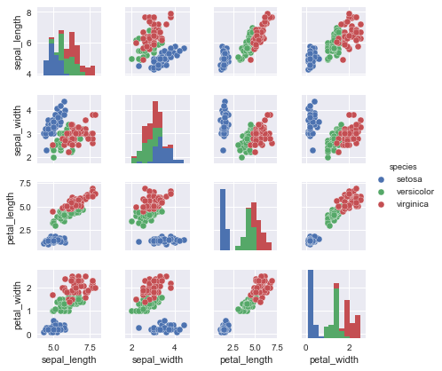

```python
%matplotlib inline
sns.set() # 使用seaborn的默认主题
sns.pairplot(iris,hue="species",size=1.5)
```

```python
X_iris = iris.drop("species",axis=1)
X_iris.shape
```

```
(150, 4)
```

```python
Y_iris = iris['species']
Y_iris.shape
```

```
(150,)
```

## Scikit-Learn的评估器API

```
.统一性
所有对象使用共同接口连接一组方法和统一的文档。
```

```
.内省
所有参数值都是公共属性。
```

```
.限制对象层级
只有算法可以使用Python类表示。数据集都用标准数据类型（NumPy数组、Pandas、DataFrame、SciPy稀疏矩阵）表示，参数名称用标准的Python字符串。
```

```
.函数组合
许多机器学习任务都可以用一串基本算法实现，Scikit-Learn尽力支持这种可能。
```

```
.明智的默认值
当模型需要用户设置参数时，Scikit-Learn预先定义适当的默认值。
```

### API基础知识

```
（1）通过从Scikit-Learn中导入适当的评估器类，选择模型类。

（2）用合适的数值对模型类实例化，配置模型超参数（hyperparameter）。

（3）整理数据，通过前面介绍的方法获取特征矩阵和目标数组。

（4）调用模型实例的fit()方法对数据进行拟合。

（5）对新数据应用模型：

    .在有监督学习模型中，通常使用predict()方法预测新数据的标签；

    .在无监督学习模型中，通常使用transform()或predict()方法转换或推断数据的性质。
```

### 有监督：简单线性回归示例

```python
import matplotlib.pyplot as plt
import numpy as np
```

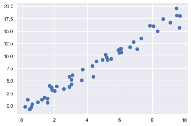

```python
rng = np.random.RandomState(42)
x = 10 * rng.rand(50)
y = 2 * x - 1 + rng.randn(50)
plt.scatter(x,y)
```

**step 1 : 选择模型类**

```python
from sklearn.linear_model import LinearRegression
```

**step 2 : 选择超参数，类实例化**

```python
model = LinearRegression(fit_intercept=True)
```

**step 3 : 按照之前提到的Scikit-Learn的数据表示方法整理数据**

```python
X = x[:,np.newaxis]
X.shape
```

```
(50, 1)
```

**step 4 : 训练、拟合**

```python
model.fit(X,y)
```

```
LinearRegression(copy_X=True, fit_intercept=True, n_jobs=1, normalize=False)
```

训练结果存储在模型属性中，在Scikit-Learn中，所有通过fit()方法获得的模型参数都带一条下划线。

```python
model.coef_
```

```
array([1.9776566])
```

```python
model.intercept_
```

```
-0.9033107255311164
```

**step 5 : 预测**

```python
xfit = np.linspace(-1,11)
Xfit = xfit[:,np.newaxis]
yfit = model.predict(Xfit)
```

可视化

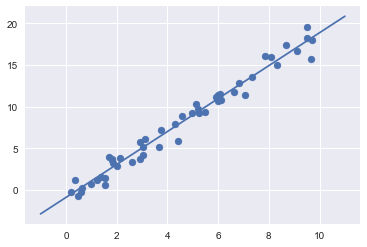

```python
plt.scatter(x,y)
plt.plot(xfit,yfit)  # plot x and y using default line style and color
```

### 有监督：鸢尾花分类示例

这里使用非常简单的**高斯朴素贝叶斯（Gaussian naive Bayes）**方法，“朴素贝叶斯方法实际上学习到生成数据的机制，所以属于生成模型。条件独立假设等于是说用于分类的特征在类确定的条件下都是条件独立的。这一假设使朴素贝叶斯法变得简单，但有时会牺牲一定的分类准确率。”（李航《统计学习方法》），朴素贝叶斯的参数估计包括极大似然估计和贝叶斯估计，贝叶斯估计解决极大似然估计可能会出现所要估计的概率值为0的情况。

因为高斯朴素贝叶斯方法速度很快，不需要选择超参数，所以通常很**适合作为初步分类手段**。

```python
from sklearn.cross_validation import train_test_split
Xtrain,Xtest,ytrain,ytest = train_test_split(X_iris,Y_iris,random_state=1)
```

```python
from sklearn.naive_bayes import GaussianNB
model = GaussianNB()
model.fit(Xtrain,ytrain)
y_model = model.predict(Xtest)
```

```python
from sklearn.metrics import accuracy_score
accuracy_score(y_model,ytest)
```

```
0.9736842105263158
```

### 无监督：鸢尾花数据降维示例

降维的任务是要找到一个可以保留数据本质特征的低维矩阵来表示高维数据。主成分分析（Principal Component Analysis，PCA）方法是一种快速线性降维技术。

```python
from sklearn.decomposition import PCA
model = PCA(n_components=2)
model.fit(X_iris)
X_2D = model.transform(X_iris)
```

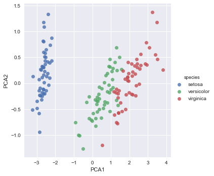

```python
iris['PCA1'] = X_2D[:,0]
iris['PCA2'] = X_2D[:,1]
sns.lmplot('PCA1','PCA2',hue='species',data=iris,fit_reg=False)
```

### 无监督：鸢尾花数据聚类

聚类算法是要对没有任何标签的数据集进行分组。这里使用[**高斯混合模型（Gaussian mixture model，GMM）**](http://www.ituring.com.cn/article/497545),高斯混合模型是对高斯模型进行简单的扩展，GMM使用**多个高斯分布的组合**来刻画数据分布。

```python
from sklearn.mixture import GaussianMixture
```

```python
model = GaussianMixture(n_components=3,covariance_type='full')
model.fit(X_iris)
y_gmm = model.predict(X_iris)
```

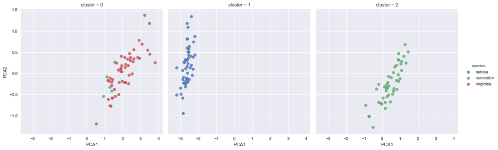

```python
iris['cluster'] = y_gmm
sns.lmplot('PCA1','PCA2',data=iris,hue='species',col='cluster',fit_reg=False)
```

## 应用：手写数字探索

### 加载并可视化手写数字

```python
from sklearn.datasets import load_digits
```

```python
digits = load_digits()
digits.images.shape
```

```
(1797, 8, 8)
```

```python
import matplotlib.pyplot as plt
```

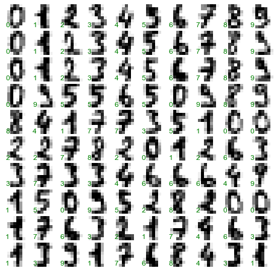

```python
fig, axes = plt.subplots(10, 10, figsize=(8, 8),
                         subplot_kw={'xticks':[], 'yticks':[]},
                         gridspec_kw=dict(hspace=0.1, wspace=0.1))
for i, ax in enumerate(axes.flat):
    ax.imshow(digits.images[i], cmap='binary', interpolation='nearest')
    ax.text(0.05, 0.05, str(digits.target[i]),
            transform=ax.transAxes, color='green')
```

```python
X = digits.data
X.shape
```

```
(1797, 64)
```

```python
y = digits.target
y.shape
```

```
(1797,)
```

### 无监督学习：降维

64维参数空间可视化十分困难，借助无监督学习方法将维度降到二维，使用流形学习算法中的Isomap算法对数据降维。

```python
from sklearn.manifold import Isomap
iso = Isomap(n_components=2)
iso.fit(digits.data)
data_projected = iso.transform(digits.data)
data_projected.shape
```

```
(1797, 2)
```

可视化：

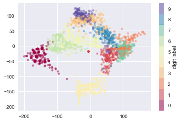

```python
plt.scatter(data_projected[:, 0], data_projected[:, 1], c=digits.target, s=20,
            edgecolor='none', alpha=0.5,
            cmap=plt.cm.get_cmap('Spectral', 10))
plt.colorbar(label='digit label', ticks=range(10))
plt.clim(-0.5, 9.5);
```

### 数字分类

```python
Xtrain,Xtest,ytrain,ytest = train_test_split(X,y,random_state = 0)# random_state : int, RandomState instance or None, optional (default=None)
                                                  # If int, random_state is the seed used by the random number generator;
```

```python
from sklearn.naive_bayes import GaussianNB
model = GaussianNB()
model.fit(Xtrain,ytrain)
y_model = model.predict(Xtest)
```

```python
from sklearn.metrics import accuracy_score
accuracy_score(y_model,ytest)
```

```
0.8333333333333334
```

混淆矩阵

```
Text(0.5,16,'true value')
```

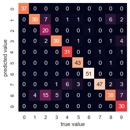

```python
from sklearn.metrics import confusion_matrix

mat = confusion_matrix(y_model,ytest)

sns.heatmap(mat,square=True,annot = True,cbar= False)
plt.ylabel("predicted value")
plt.xlabel("true value")
```

可以发现，很多数字2被误判为8或1.

另一种表示方法是将样本画出来，把预测值写在左下角，绿色表示正确，红色表示错误。

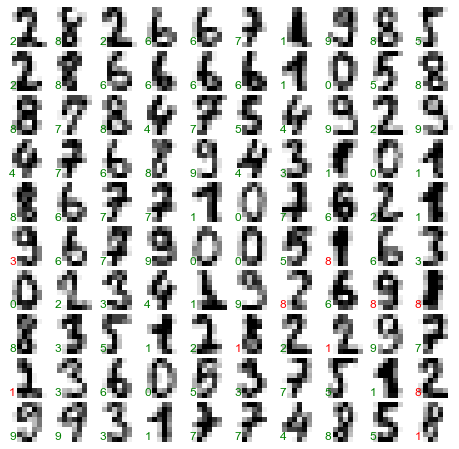

```python
fig, axes = plt.subplots(10, 10, figsize=(8, 8),
                         subplot_kw={'xticks':[], 'yticks':[]},
                         gridspec_kw=dict(hspace=0.1, wspace=0.1))

test_images = Xtest.reshape(-1, 8, 8)

for i, ax in enumerate(axes.flat):
    ax.imshow(test_images[i], cmap='binary', interpolation='nearest')
    ax.text(0.05, 0.05, str(y_model[i]),
            transform=ax.transAxes,
            color='green' if (ytest[i] == y_model[i]) else 'red')
```

## 其他资料

matplotlib-tutorial

[scikit-learn（sklearn） 中文文档](https://github.com/apachecn/scikit-learn-doc-zh)